← Volver al inicio← Repaso teórico

# Taller Simulaciones Montecarlo — Solución

Solución completa del `Taller Simulaciones Montecarlo.pdf` (agosto 2026). Cada pregunta del enunciado se cita textualmente antes de resolverla, y cada resultado cierra con una línea **Respuesta:** explícita.

▸ código

```r
if (!require("pacman")) install.packages("pacman")
```

▸ código

```r
pacman::p_load(tidyverse, EnvStats, ggpubr, psych, readr, scales, quantmod, xts, TTR)
options(scipen = 999)
```

# Ejercicio 1 — Tiempo de falla de un satélite

> “Se tiene un satélite, que para su funcionamiento depende de que al menos 2 paneles solares, de los 5 que tiene disponibles, estén en funcionamiento. Se quiere calcular la vida útil esperada del satélite (MTTF).”
> - Paneles 1 y 2: Normal(media = 50,000 h, desv = 5,000 h)
> - Paneles 3 y 4: Triangular(mín = 30,000 h, máx = 75,000 h, moda = 50,000 h)
> - Panel 5: Normal(media = 55,000 h, desv = 8,000 h)

## Planteamiento del modelo

El satélite necesita **al menos 2 de 5** paneles funcionando. Si ordenamos las 5 vidas útiles simuladas de menor a mayor $T_{(1)} \le T_{(2)} \le T_{(3)} \le T_{(4)} \le T_{(5)}$, el satélite sigue operando mientras fallan el 1°, 2° y 3° panel (todavía quedan 2 funcionando). **Falla exactamente en el momento $T_{(4)}$**, cuando el cuarto panel se apaga y solo queda 1 (ya no cumple el mínimo de 2). Por lo tanto, la vida útil del satélite en cada simulación es el **4° estadístico de orden** (el 2° valor más alto) de las 5 vidas útiles simuladas — la lógica estándar de un sistema de confiabilidad “k-de-n” (aquí, 2-de-5).

▸ código

```r
simular_satelite <- function(n_sim) {
  panel1 <- rnorm(n_sim, mean = 50000, sd = 5000)
  panel2 <- rnorm(n_sim, mean = 50000, sd = 5000)
  panel3 <- EnvStats::rtri(n_sim, min = 30000, max = 75000, mode = 50000)
  panel4 <- EnvStats::rtri(n_sim, min = 30000, max = 75000, mode = 50000)
  panel5 <- rnorm(n_sim, mean = 55000, sd = 8000)

  paneles <- cbind(panel1, panel2, panel3, panel4, panel5)
  # sort(fila)[4] = 4to estadistico de orden de las 5 vidas de panel
  vida_satelite <- apply(paneles, 1, function(fila) sort(fila)[4])
  return(vida_satelite)
}
```

## n = 100

▸ código

```r
set.seed(2026)
vida_100 <- simular_satelite(100)

media_100 <- mean(vida_100)
sd_100 <- sd(vida_100)
cuartiles_100 <- quantile(vida_100, probs = c(0.25, 0.5, 0.75))
p5_100 <- quantile(vida_100, probs = 0.05)
p95_100 <- quantile(vida_100, probs = 0.95)

cat("Media:", media_100, "\n")
```

```
## Media: 54763.96
```

▸ código

```r
cat("Desviación estándar:", sd_100, "\n")
```

```
## Desviación estándar: 4330.054
```

▸ código

```r
cat("Cuartiles:\n"); print(cuartiles_100)
```

```
## Cuartiles:
```

```
##      25%      50%      75%
## 51619.01 55097.08 57599.35
```

▸ código

```r
cat("Percentil 5% (peores):", p5_100, "\n")
```

```
## Percentil 5% (peores): 48062.43
```

▸ código

```r
cat("Percentil 95% (mejores):", p95_100, "\n")
```

```
## Percentil 95% (mejores): 61491.92
```

▸ código

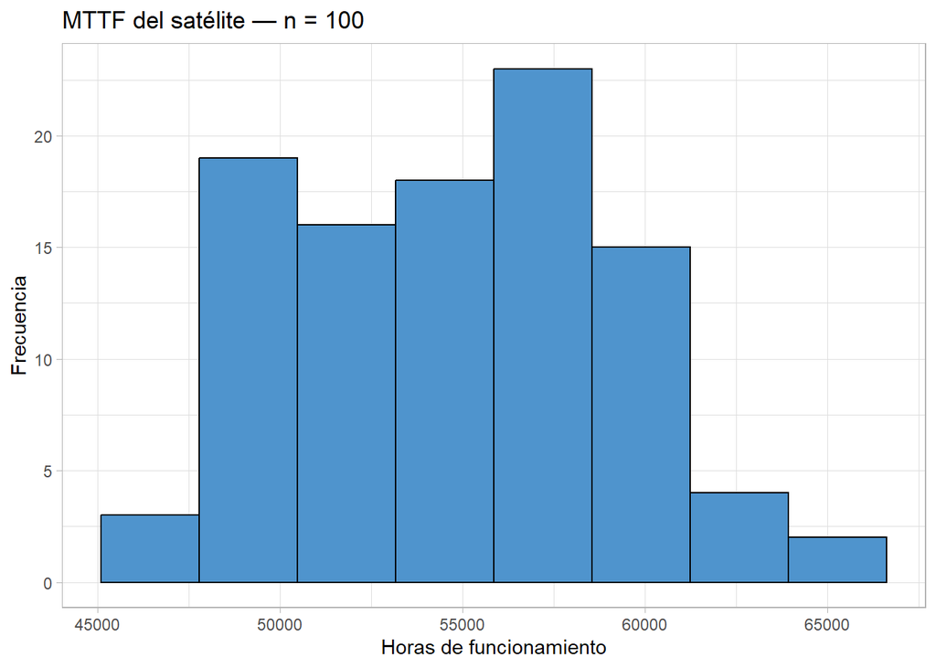

```r
ggplot(data.frame(vida = vida_100), aes(vida)) +
  geom_histogram(color = "black", fill = "steelblue3", bins = nclass.Sturges(vida_100)) +
  theme_light() +
  labs(x = "Horas de funcionamiento", y = "Frecuencia", title = "MTTF del satélite — n = 100")
```

> 1. El tiempo promedio de funcionamiento.

**Respuesta:** con n = 100, el tiempo promedio de funcionamiento (MTTF) es **54764 horas**.

> 2. La desviación estándar del tiempo de funcionamiento.

**Respuesta:** la desviación estándar es **4330 horas**.

> 3. Los cuartiles del tiempo de funcionamiento.

**Respuesta:** Q1 = 51619 h, Q2 (mediana) = 55097 h, Q3 = 57599 h.

> 4. Construya el histograma de los tiempos de funcionamiento.

**Respuesta:** ver histograma arriba.

> 5. ¿Hasta qué tiempo se encuentra el 5% de los peores tiempos de funcionamiento?

**Respuesta:** el 5% de los peores casos tiene una vida útil de **48062 horas o menos**.

> 6. ¿Hasta qué tiempo se encuentra el 5% de los mejores tiempos de funcionamiento?

**Respuesta:** el 5% de los mejores casos tiene una vida útil de **61492 horas o más**.

## n = 1,000

▸ código

```r
set.seed(2026)
vida_1000 <- simular_satelite(1000)

media_1000 <- mean(vida_1000)
sd_1000 <- sd(vida_1000)
cuartiles_1000 <- quantile(vida_1000, probs = c(0.25, 0.5, 0.75))
p5_1000 <- quantile(vida_1000, probs = 0.05)
p95_1000 <- quantile(vida_1000, probs = 0.95)

cat("Media:", media_1000, "\n")
```

```
## Media: 55105.23
```

▸ código

```r
cat("Desviación estándar:", sd_1000, "\n")
```

```
## Desviación estándar: 4398.401
```

▸ código

```r
cat("Cuartiles:\n"); print(cuartiles_1000)
```

```
## Cuartiles:
```

```
##      25%      50%      75%
## 51939.57 54567.57 57805.55
```

▸ código

```r
cat("Percentil 5% (peores):", p5_1000, "\n")
```

```
## Percentil 5% (peores): 48578.71
```

▸ código

```r
cat("Percentil 95% (mejores):", p95_1000, "\n")
```

```
## Percentil 95% (mejores): 62918.44
```

▸ código

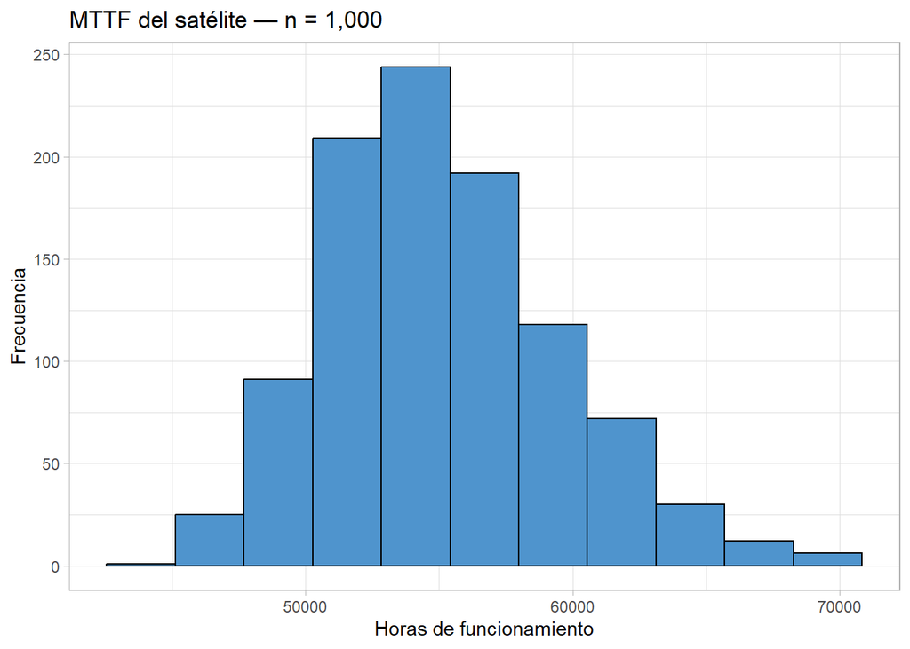

```r
ggplot(data.frame(vida = vida_1000), aes(vida)) +
  geom_histogram(color = "black", fill = "steelblue3", bins = nclass.Sturges(vida_1000)) +
  theme_light() +
  labs(x = "Horas de funcionamiento", y = "Frecuencia", title = "MTTF del satélite — n = 1,000")
```

**Respuesta (1. Tiempo promedio):** 55105 horas.

**Respuesta (2. Desviación estándar):** 4398 horas.

**Respuesta (3. Cuartiles):** Q1 = 51940 h, Q2 = 54568 h, Q3 = 57806 h.

**Respuesta (4. Histograma):** ver arriba.

**Respuesta (5. Peor 5%):** 48579 horas o menos.

**Respuesta (6. Mejor 5%):** 62918 horas o más.

## n = 10,000

▸ código

```r
set.seed(2026)
vida_10000 <- simular_satelite(10000)

media_10000 <- mean(vida_10000)
sd_10000 <- sd(vida_10000)
cuartiles_10000 <- quantile(vida_10000, probs = c(0.25, 0.5, 0.75))
p5_10000 <- quantile(vida_10000, probs = 0.05)
p95_10000 <- quantile(vida_10000, probs = 0.95)

cat("Media:", media_10000, "\n")
```

```
## Media: 55314.42
```

▸ código

```r
cat("Desviación estándar:", sd_10000, "\n")
```

```
## Desviación estándar: 4460.905
```

▸ código

```r
cat("Cuartiles:\n"); print(cuartiles_10000)
```

```
## Cuartiles:
```

```
##      25%      50%      75%
## 52220.95 54969.91 58061.02
```

▸ código

```r
cat("Percentil 5% (peores):", p5_10000, "\n")
```

```
## Percentil 5% (peores): 48592.32
```

▸ código

```r
cat("Percentil 95% (mejores):", p95_10000, "\n")
```

```
## Percentil 95% (mejores): 63286.36
```

▸ código

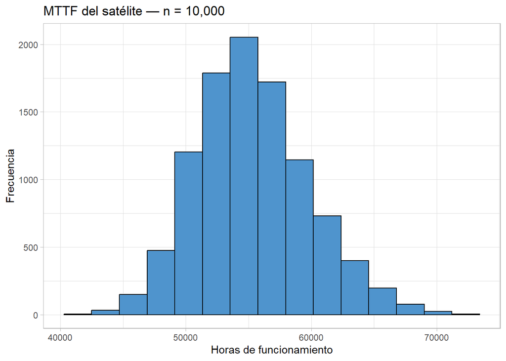

```r
ggplot(data.frame(vida = vida_10000), aes(vida)) +
  geom_histogram(color = "black", fill = "steelblue3", bins = nclass.Sturges(vida_10000)) +
  theme_light() +
  labs(x = "Horas de funcionamiento", y = "Frecuencia", title = "MTTF del satélite — n = 10,000")
```

**Respuesta (1. Tiempo promedio):** 55314 horas.

**Respuesta (2. Desviación estándar):** 4461 horas.

**Respuesta (3. Cuartiles):** Q1 = 52221 h, Q2 = 54970 h, Q3 = 58061 h.

**Respuesta (4. Histograma):** ver arriba.

**Respuesta (5. Peor 5%):** 48592 horas o menos.

**Respuesta (6. Mejor 5%):** 63286 horas o más.

## Comparación entre las tres simulaciones

> “Compare los resultados obtenidos en las tres simulaciones y justifique las diferencias, en caso de que existan.”

▸ código

```r
tabla_satelite <- data.frame(
  n = c(100, 1000, 10000),
  media = c(media_100, media_1000, media_10000),
  desv_estandar = c(sd_100, sd_1000, sd_10000),
  q1 = c(cuartiles_100[1], cuartiles_1000[1], cuartiles_10000[1]),
  mediana = c(cuartiles_100[2], cuartiles_1000[2], cuartiles_10000[2]),
  q3 = c(cuartiles_100[3], cuartiles_1000[3], cuartiles_10000[3]),
  p5_peores = c(p5_100, p5_1000, p5_10000),
  p95_mejores = c(p95_100, p95_1000, p95_10000)
)
tabla_satelite
```

| n | media | desv_estandar | q1 | mediana | q3 | p5_peores | p95_mejores |
| --- | --- | --- | --- | --- | --- | --- | --- |
| 100 | 54763.96 | 4330.054 | 51619.01 | 55097.08 | 57599.35 | 48062.43 | 61491.92 |
| 1000 | 55105.23 | 4398.401 | 51939.57 | 54567.57 | 57805.55 | 48578.71 | 62918.44 |
| 10000 | 55314.42 | 4460.905 | 52220.95 | 54969.91 | 58061.02 | 48592.32 | 63286.36 |

**Respuesta:** la media (54764 → 55105 → 55314 horas) y la mediana casi no cambian entre las tres simulaciones — una diferencia de apenas 1.01% entre n=100 y n=10,000. Esto confirma que **100 iteraciones ya alcanzan para estimar bien las medidas de tendencia central** (media, mediana, cuartiles), tal como se vio en clase.

Donde sí hay una diferencia real es en los **percentiles extremos**: el percentil 5% (peor caso) pasa de 48062 (n=100) a 48579 (n=1,000) a 48592 horas (n=10,000) — un movimiento de 530 horas entre el extremo y el otro. La razón: con n=100 solo hay **~5 observaciones** en esa cola (5% de 100), una muestra minúscula y ruidosa que cambia mucho si se repite la simulación; con n=10,000 hay **~500 observaciones** en la misma cola, dando una estimación mucho más estable. **Esto es exactamente lo que se explicó en clase**: pocas iteraciones alcanzan para el promedio, pero hacen falta muchas más para hablar en serio de las colas de la distribución (el peor/mejor escenario).

# Ejercicio 2 — Sensibilidad del VPN a la volatilidad del precio

> “Considere el caso del ejemplo en caso del proyecto evaluado a partir del VPN. Muestre cómo cambian los resultados de la simulación del VPN si se aumenta la volatilidad del precio de venta del producto de 20 a 35.”

Se usa la misma semilla en ambas corridas — como `costos` y `ventas` se generan *después* de `precios` en la secuencia de números aleatorios, y cambiar solo el parámetro `sd` de `rnorm()` no cambia cuántos números aleatorios consume, ambas corridas usan exactamente los mismos `costos`/`ventas` simulados. Así el único factor que cambia es la volatilidad del precio.

▸ código

```r
simular_vpn <- function(sd_precio, seed = 41677, n_sim = 10000) {
  set.seed(seed)
  inv_inicial <- 200000
  tasa <- 0.10
  tiempo <- 2

  precios <- rnorm(n = n_sim, mean = 200, sd = sd_precio)
  costos <- EnvStats::rtri(n = n_sim, min = 80, max = 130, mode = 100)
  ventas <- rlnorm(n = n_sim, meanlog = log(5000), sdlog = 0.2) %>% round(0)

  utilidad <- (precios - costos) * ventas
  vpn <- (utilidad / (1 + tasa)^tiempo) - inv_inicial
  return(vpn)
}

vpn_sd20 <- simular_vpn(sd_precio = 20)
vpn_sd35 <- simular_vpn(sd_precio = 35)

prob_exito_20 <- mean(vpn_sd20 > 0) * 100
prob_exito_35 <- mean(vpn_sd35 > 0) * 100
vpn_esp_20 <- mean(vpn_sd20)
vpn_esp_35 <- mean(vpn_sd35)
vpn_sd_20 <- sd(vpn_sd20)
vpn_sd_35 <- sd(vpn_sd35)
p5_vpn_20 <- quantile(vpn_sd20, 0.05)
p5_vpn_35 <- quantile(vpn_sd35, 0.05)
p95_vpn_20 <- quantile(vpn_sd20, 0.95)
p95_vpn_35 <- quantile(vpn_sd35, 0.95)

comparacion_vpn <- data.frame(
  escenario = c("sd = 20 (original)", "sd = 35 (nuevo)"),
  prob_exito_pct = c(prob_exito_20, prob_exito_35),
  vpn_esperado = c(vpn_esp_20, vpn_esp_35),
  vpn_sd = c(vpn_sd_20, vpn_sd_35),
  p5 = c(p5_vpn_20, p5_vpn_35),
  p95 = c(p95_vpn_20, p95_vpn_35)
)
comparacion_vpn
```

| escenario | prob_exito_pct | vpn_esperado | vpn_sd | p5 | p95 |
| --- | --- | --- | --- | --- | --- |
| sd = 20 (original) | 97.18 | 207342.8 | 125906.7 | 22802.78 | 433151.1 |
| sd = 35 (nuevo) | 89.56 | 206584.1 | 175855.1 | -53846.80 | 513329.7 |

▸ código

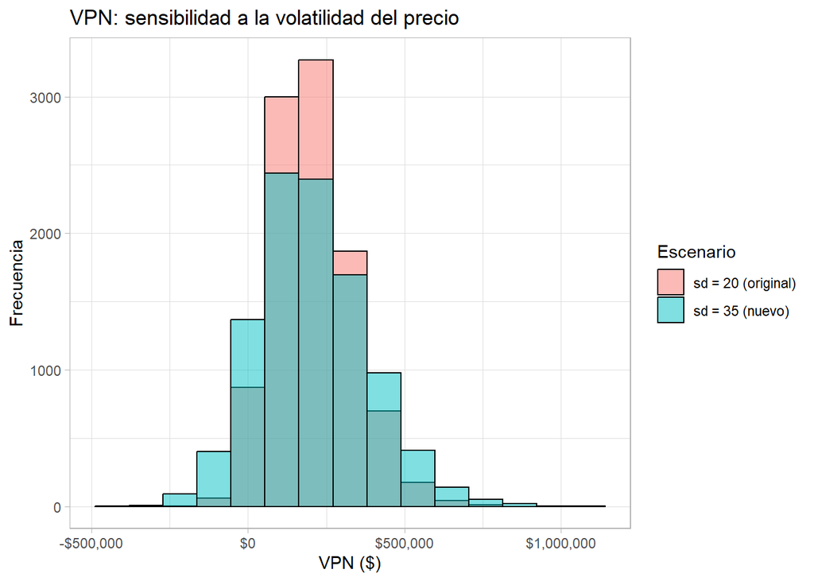

```r
datos_vpn_comb <- bind_rows(
  data.frame(vpn = vpn_sd20, escenario = "sd = 20 (original)"),
  data.frame(vpn = vpn_sd35, escenario = "sd = 35 (nuevo)")
)

ggplot(datos_vpn_comb, aes(x = vpn, fill = escenario)) +
  geom_histogram(position = "identity", alpha = 0.5, color = "black",
                 bins = nclass.Sturges(vpn_sd20)) +
  theme_light() +
  labs(x = "VPN ($)", y = "Frecuencia", fill = "Escenario",
       title = "VPN: sensibilidad a la volatilidad del precio") +
  scale_x_continuous(labels = label_currency())
```

**Respuesta:** al subir la desviación estándar del precio de 20 a 35:

- **Probabilidad de éxito** (VPN > 0): baja de **97.18%** a **89.56%** — una caída de 7.62 puntos porcentuales.
- **VPN esperado**: prácticamente no cambia ($207,343 → $206,584, una diferencia de solo 0.37%). Esto es esperado: subir la volatilidad del precio no cambia su *media* (sigue en 200), y la utilidad es lineal en el precio, así que el efecto sobre el VPN esperado es de segundo orden.
- **Dispersión del VPN** (desviación estándar): sube de $125,907 a $175,855 — casi se **1.4x** su tamaño original.
- **Percentil 5% (peor caso)**: pasa de $22,803 (positivo) a **-$53,847** (negativo) — el peor escenario del proyecto pasa de ser rentable a generar pérdidas.
- **Percentil 95% (mejor caso)**: sube de $433,151 a $513,330.

En conclusión: aumentar la volatilidad del precio **no mueve el resultado esperado**, pero **sí aumenta fuertemente el riesgo** del proyecto — la distribución del VPN se ensancha hacia ambos lados, y el peor escenario pasa de ganancia a pérdida.

# Ejercicio 3 — Crecimiento de una inversión con una acción real

> “Considere una acción que se comercialice en las bolsas de valores de EE.UU. Para esta acción debe descargar los precios de cierre ajustados entre el 31/12/2021 y el 31/07/2026.”

Se usa **Apple (AAPL)**, acción líquida y ampliamente cotizada en NASDAQ, con precios de cierre ajustados descargados directamente de Yahoo Finance (mismo método usado en `Distribuciones y correlaciones.R`: `quantmod::getSymbols` → `xts::to.monthly`).

▸ código

```r
accion <- "AAPL"

precio_diario <- quantmod::getSymbols(accion, src = "yahoo",
                                       from = "2021-12-31",
                                       to = "2026-07-31",
                                       periodicity = "daily",
                                       auto.assign = FALSE,
                                       warnings = FALSE)

precio_ajustado_diario <- quantmod::Ad(precio_diario)

precio_mensual <- xts::to.monthly(precio_ajustado_diario,
                                   indexAt = "lastof",
                                   OHLC = FALSE)

# NOTA: TTR::ROC(x, type="continuous", na.pad=FALSE) da un primer valor
# incorrecto en series univariadas (devuelve log(x_2) en vez de log(x_2/x_1)
# para la primera fila) - verificado manualmente contra diff(log(precio)).
# Se calcula el retorno logaritmico directamente para evitar ese bug.
retornos_accion <- na.omit(diff(log(precio_mensual)))
```

> “Con esta información usted debe: Calcular el retorno mensual promedio de la acción. Calcular la desviación estándar de los retornos mensuales de la acción. Calcular el retorno mensual máximo y el retorno mensual mínimo de la acción.”

▸ código

```r
media_accion <- mean(retornos_accion)
sd_accion <- sd(retornos_accion)
max_accion <- max(retornos_accion)
min_accion <- min(retornos_accion)

data.frame(
  accion = accion,
  retorno_mensual_promedio_pct = media_accion * 100,
  desv_estandar_pct = sd_accion * 100,
  retorno_max_pct = max_accion * 100,
  retorno_min_pct = min_accion * 100
)
```

| accion | retorno_mensual_promedio_pct | desv_estandar_pct | retorno_max_pct | retorno_min_pct |
| --- | --- | --- | --- | --- |
| AAPL | 1.186699 | 7.329311 | 17.28045 | -13.04187 |

**Respuesta:** para AAPL entre 2021-12-31 y 2026-07-31, el retorno mensual promedio es **1.19%**, la desviación estándar mensual es **7.33%**, el retorno mensual máximo observado fue **17.28%** y el mínimo fue **-13.04%**.

## Parte 1 — n = 51, a 2 años (24 meses), $100,000 inicial

> “1. Realizar dos simulaciones de tamaño n = 51 de cómo se comportará una inversión de $100,000 dólares si se invierten, a dos años, en un activo cuyos retornos son aleatorios y siguen: a. Una distribución normal. b. Una distribución triangular (emplee la media estimada como aproximación de la moda). Para ambos casos se debe graficar la simulación y se deben de calcular las estadísticas descriptivas y comparar los resultados.”

Se reusa la función `simulacion_activo()` de `Simulaciones.R` para la normal, y se crea su equivalente con `rtri()` para la triangular (usando la media observada como aproximación de la moda, tal como pide el enunciado).

▸ código

```r
simulacion_activo <- function(valor_inicial, media_rendimiento, sd_rendimiento, periodos){
  activo <- data.frame(periodo = 0:periodos) %>%
    mutate(retorno = c(0, rnorm(n = periodos, mean = media_rendimiento, sd = sd_rendimiento))) %>%
    mutate(rendimiento = 1 + retorno) %>%
    mutate(rend_acum = cumprod(rendimiento)) %>%
    mutate(retorno_acum = rend_acum - 1) %>%
    mutate(capital = valor_inicial * rend_acum, .after = 1)
  return(activo)
}

simulacion_activo_tri <- function(valor_inicial, minimo, maximo, moda, periodos){
  activo <- data.frame(periodo = 0:periodos) %>%
    mutate(retorno = c(0, EnvStats::rtri(n = periodos, min = minimo, max = maximo, mode = moda))) %>%
    mutate(rendimiento = 1 + retorno) %>%
    mutate(rend_acum = cumprod(rendimiento)) %>%
    mutate(retorno_acum = rend_acum - 1) %>%
    mutate(capital = valor_inicial * rend_acum, .after = 1)
  return(activo)
}

capital_inicial <- 100000
periodos_2a <- 24
n_51 <- 51
```

### a. Distribución normal

▸ código

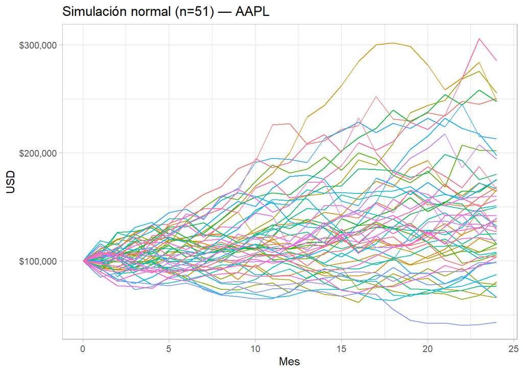

```r
set.seed(300)
sim_normal_51 <- purrr::map(.x = rep(capital_inicial, n_51),
                            .f = simulacion_activo,
                            media_rendimiento = media_accion,
                            sd_rendimiento = sd_accion,
                            periodos = periodos_2a) %>%
  list_rbind(names_to = "simulacion") %>%
  mutate(simulacion = factor(simulacion))

ggplot(sim_normal_51, aes(x = periodo, y = capital, col = simulacion)) +
  geom_line() +
  theme_light() +
  theme(legend.position = "none") +
  labs(x = "Mes", y = "USD", title = paste0("Simulación normal (n=", n_51, ") — ", accion)) +
  scale_y_continuous(labels = label_currency())
```

▸ código

```r
final_normal_51 <- sim_normal_51 %>% group_by(simulacion) %>% summarise(final = last(capital)) %>% pull(final)
media_normal_51 <- mean(final_normal_51)
sd_normal_51 <- sd(final_normal_51)
mediana_normal_51 <- median(final_normal_51)
print(psych::describe(final_normal_51))
```

```
##    vars  n     mean       sd   median  trimmed     mad      min      max
## X1    1 51 143253.5 53346.47 132190.7 138756.7 49166.8 43325.39 285152.6
##       range      skew   kurtosis   se
## X1 241827.2 0.6762746 0.02248271 7470
```

**Respuesta (normal, n=51):** capital final promedio = $143,254, desviación estándar = $53,346, mediana = $132,191.

### b. Distribución triangular

▸ código

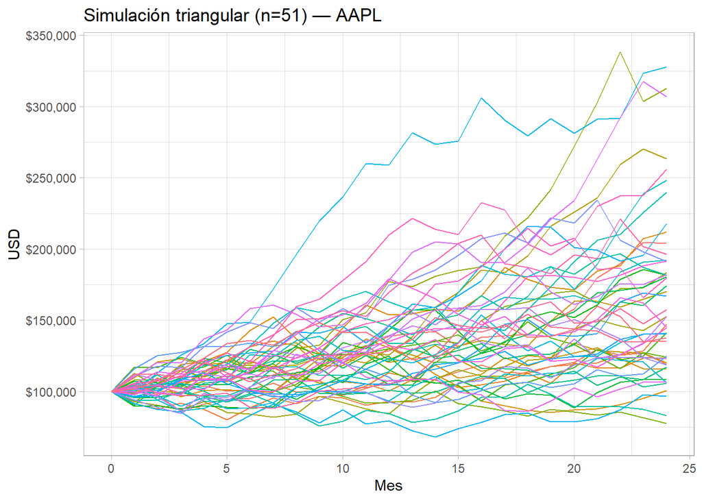

```r
set.seed(301)
sim_tri_51 <- purrr::map(.x = rep(capital_inicial, n_51),
                         .f = simulacion_activo_tri,
                         minimo = min_accion,
                         maximo = max_accion,
                         moda = media_accion,
                         periodos = periodos_2a) %>%
  list_rbind(names_to = "simulacion") %>%
  mutate(simulacion = factor(simulacion))

ggplot(sim_tri_51, aes(x = periodo, y = capital, col = simulacion)) +
  geom_line() +
  theme_light() +
  theme(legend.position = "none") +
  labs(x = "Mes", y = "USD", title = paste0("Simulación triangular (n=", n_51, ") — ", accion)) +
  scale_y_continuous(labels = label_currency())
```

▸ código

```r
final_tri_51 <- sim_tri_51 %>% group_by(simulacion) %>% summarise(final = last(capital)) %>% pull(final)
media_tri_51 <- mean(final_tri_51)
sd_tri_51 <- sd(final_tri_51)
mediana_tri_51 <- median(final_tri_51)
print(psych::describe(final_tri_51))
```

```
##    vars  n     mean       sd   median  trimmed      mad      min      max
## X1    1 51 165168.8 58287.84 152484.5 158370.2 49635.51 77572.86 327805.3
##       range      skew  kurtosis       se
## X1 250232.4 0.9823409 0.5085349 8161.931
```

**Respuesta (triangular, n=51):** capital final promedio = $165,169, desviación estándar = $58,288, mediana = $152,484.

### Comparación normal vs. triangular (n = 51)

**Respuesta:** con n=51, la simulación **triangular da un capital final promedio más alto** ($165,169 vs. $143,254 de la normal, una diferencia de 15.3%) y **algo más de dispersión** ($58,288 vs. $53,346). Con solo 51 simulaciones esta comparación todavía tiene bastante ruido de muestreo — se retoma con más precisión en la Parte 2 (n=100,000).

## Parte 2 — n = 100,000 iteraciones (sin gráfico)

> “2. Usando la misma información del punto anterior, se debe de realizar las dos simulaciones. Pero esta vez se debe de realizar n = 100,000 iteraciones en las dos simulaciones (no realices el gráfico de la simulación).”

**Nota de implementación**: para 100,000 iteraciones se necesita solo el capital *final* de cada corrida, no la trayectoria mes a mes completa. Probamos primero usar exactamente la misma función `simulacion_activo()` de la Parte 1 (el mismo estilo `purrr::map` + `dplyr` visto en clase) para 100,000 repeticiones, y **tardó cerca de 29 minutos solo para la distribución normal** (serían ~1 hora para las dos) — computacionalmente inviable para este taller. Por eso aquí se vectoriza el cálculo (una matriz de retornos de 100,000 × 24, con el producto acumulado por fila) en vez de llamar la función 100,000 veces — el resultado matemático es idéntico, solo cambia cómo se calcula.

▸ código

```r
n_100k <- 100000

set.seed(302)
retornos_normal_100k <- matrix(rnorm(n_100k * periodos_2a, mean = media_accion, sd = sd_accion),
                                nrow = n_100k, ncol = periodos_2a)
final_normal_100k <- capital_inicial * apply(1 + retornos_normal_100k, 1, prod)

set.seed(303)
retornos_tri_100k <- matrix(EnvStats::rtri(n_100k * periodos_2a, min = min_accion, max = max_accion, mode = media_accion),
                             nrow = n_100k, ncol = periodos_2a)
final_tri_100k <- capital_inicial * apply(1 + retornos_tri_100k, 1, prod)

media_normal_100k <- mean(final_normal_100k)
sd_normal_100k <- sd(final_normal_100k)
mediana_normal_100k <- median(final_normal_100k)

media_tri_100k <- mean(final_tri_100k)
sd_tri_100k <- sd(final_tri_100k)
mediana_tri_100k <- median(final_tri_100k)

cat("--- Normal (n=100,000) ---\n")
```

```
## --- Normal (n=100,000) ---
```

▸ código

```r
print(psych::describe(final_normal_100k))
```

```
##    vars      n     mean       sd   median  trimmed      mad     min      max
## X1    1 100000 132799.2 48546.39 124737.5 128293.4 43806.91 24920.9 583697.7
##       range     skew kurtosis       se
## X1 558776.8 1.091992 2.129382 153.5172
```

▸ código

```r
cat("\n--- Triangular (n=100,000) ---\n")
```

```
##
## --- Triangular (n=100,000) ---
```

▸ código

```r
print(psych::describe(final_tri_100k))
```

```
##    vars      n   mean       sd   median  trimmed      mad      min      max
## X1    1 100000 153672 46984.39 147119.9 149914.6 43685.27 37227.51 502139.5
##     range      skew kurtosis       se
## X1 464912 0.9122776 1.462925 148.5777
```

> “a. Calcular las estadísticas descriptivas y comparar los resultados con los obtenidos en las simulaciones anteriores.”

▸ código

```r
tabla_n <- data.frame(
  distribucion = c("Normal", "Normal", "Triangular", "Triangular"),
  n = c(51, 100000, 51, 100000),
  media = c(media_normal_51, media_normal_100k, media_tri_51, media_tri_100k),
  desv_estandar = c(sd_normal_51, sd_normal_100k, sd_tri_51, sd_tri_100k),
  mediana = c(mediana_normal_51, mediana_normal_100k, mediana_tri_51, mediana_tri_100k)
)
tabla_n
```

| distribucion | n | media | desv_estandar | mediana |
| --- | --- | --- | --- | --- |
| Normal | 51 | 143253.5 | 53346.47 | 132190.7 |
| Normal | 100000 | 132799.2 | 48546.39 | 124737.5 |
| Triangular | 51 | 165168.8 | 58287.84 | 152484.5 |
| Triangular | 100000 | 153672.0 | 46984.39 | 147119.9 |

**Respuesta:** al subir de n=51 a n=100,000 para la **normal**, la media pasa de $143,254 a $132,799 (diferencia de 7.3%) — un cambio pequeño, dentro de lo esperable por ruido de muestreo con solo 51 simulaciones. Para la **triangular**, la media pasa de $165,169 a $153,672 (diferencia de 7%). En ambos casos **la media ya estaba razonablemente bien estimada con n=51** — confirma, otra vez, que pocas iteraciones alcanzan para la tendencia central.

▸ código

```r
diferencia_media_pct <- (media_tri_100k - media_normal_100k) / media_normal_100k * 100
diferencia_sd_pct <- (sd_tri_100k - sd_normal_100k) / sd_normal_100k * 100
```

> “c. ¿Cuánto es lo máximo que se puede perder en el 5% de los peores casos?”

▸ código

```r
p5_normal_100k <- quantile(final_normal_100k, 0.05)
p5_tri_100k <- quantile(final_tri_100k, 0.05)
perdida_normal <- capital_inicial - p5_normal_100k
perdida_tri <- capital_inicial - p5_tri_100k

data.frame(
  distribucion = c("Normal", "Triangular"),
  capital_inicial = capital_inicial,
  percentil_5_capital_final = c(p5_normal_100k, p5_tri_100k),
  perdida_maxima_5pct = c(perdida_normal, perdida_tri),
  perdida_maxima_5pct_pct = c(perdida_normal, perdida_tri) / capital_inicial * 100
)
```

| distribucion | capital_inicial | percentil_5_capital_final | perdida_maxima_5pct | perdida_maxima_5pct_pct |
| --- | --- | --- | --- | --- |
| Normal | 100000 | 69134.96 | 30865.04 | 30.86504 |
| Triangular | 100000 | 89561.17 | 10438.83 | 10.43883 |

**Respuesta:** en el 5% de los peores casos, la pérdida máxima es de **$30,865 (30.9% del capital inicial)** si los retornos siguen una normal, y de **$10,439 (10.4%)** si siguen una triangular. La normal muestra una pérdida potencial mayor, consistente con que su cola izquierda no está acotada por el peor mes históricamente observado.